# INFSCI 2595 Final Project

Part 2B, Regression - Bayesian Linear models

Radhika Purohit

```r
knitr::opts_chunk$set(echo = TRUE)
```

```r
library(tidyverse)
```

```r
theme_set(theme_linedraw())
library(rstanarm)
options(mc.cores = parallel::detectCores())
library(corrplot)
df <- readr::read_csv("paint_project_train_data.csv", col_names = TRUE)
dfii <- df %>%
  mutate(y = boot::logit( (response - 0) / (100 - 0) ) ) %>%
  select(R, G, B,
         Lightness, Saturation, Hue,
         y)

dfii %>% glimpse()
```

```
## Rows: 835
## Columns: 7
## $ R          <dbl> 172, 26, 172, 28, 170, 175, 90, 194, 171, 122, 0, 88, 144, …
## $ G          <dbl> 58, 88, 94, 87, 66, 89, 78, 106, 68, 151, 121, 140, 82, 163…
## $ B          <dbl> 62, 151, 58, 152, 58, 65, 136, 53, 107, 59, 88, 58, 132, 50…
## $ Lightness  <chr> "dark", "dark", "dark", "dark", "dark", "dark", "dark", "da…
## $ Saturation <chr> "bright", "bright", "bright", "bright", "bright", "bright",…
## $ Hue        <dbl> 4, 31, 8, 32, 5, 6, 34, 10, 1, 21, 24, 22, 36, 16, 26, 12, …
## $ y          <dbl> -1.9924302, -2.1972246, -1.6582281, -2.1972246, -2.0907411,…
```

| In this section, will use Bayesian approach to evaluate 2 models with relatively good performance from section 2A. |
| --- |
| have opted to use `rstanarm` for Bayesian analysis. |

## Bayesian Model Fitting

- Model `Model_7` is best model according to AIC/BIC.
- Model `Model_5`is second best model according to AIC/BIC.

# Reload Models

```r
re_load_mod05 <- readr::read_rds("Model_5.rds")
re_load_mod07 <- readr::read_rds("Model_7.rds")
```

**1. Based on model `Model_05`**

```r
conflicted::conflicts_prefer(rstanarm::R2)
```

```
## [conflicted] Will prefer rstanarm::R2 over any other package.
```

```r
Mod_5 <- stan_lm(
  re_load_mod05$call$formula,
  data=dfii,
  prior = R2(location = 0.5),
  seed = 1324
)
```

**2. Based on model `Model_07`**

```r
conflicted::conflicts_prefer(rstanarm::R2)
```

```
## [conflicted] Removing existing preference.
## [conflicted] Will prefer rstanarm::R2 over any other package.
```

```r
Mod_7 <- stan_lm(
  re_load_mod07$call$formula,
  data=dfii,
  prior = R2(location = 0.5),
  seed = 1324
)
```

### Model Comparison

**Compare models based on information criterion.**

```r
# Compute loo for each model
Mod_5_loo <- rstan::loo(Mod_5, k_threshold = 0.7)
```

```
## 1 problematic observation(s) found.
## Model will be refit 1 times.
```

```
##
## Fitting model 1 out of 1 (leaving out observation 177)
```

```r
Mod_7_loo <- rstan::loo(Mod_7, k_threshold = 0.7)
```

```
## 17 problematic observation(s) found.
## Model will be refit 17 times.
```

[output not shown]

[output not shown]

[output not shown]

[output not shown]

[output not shown]

[output not shown]

[output not shown]

[output not shown]

[output not shown]

[output not shown]

[output not shown]

[output not shown]

[output not shown]

[output not shown]

[output not shown]

[output not shown]

[output not shown]

```r
# Add loo objects to the models
Mod_5$loo <- Mod_5_loo
Mod_7$loo <- Mod_7_loo

# Create stanreg_list with loo objects
my_models_loo <- stanreg_list(
  Mod_5, Mod_7,
  model_names = c("Model_5", "Model_7")
)

# Compare using loo_compare
loo_compare(my_models_loo)
```

```
## Model comparison based on LOO-CV:
##         elpd_diff se_diff
## Model_7    0.0       0.0
## Model_5 -125.1      26.3
```

The best model from the results seem to be Model_7.

### Examine Best Model

**Analyze the posterior behavior of the best model.**

#### R-squared

```r
bayes_R2(Mod_7) %>% quantile(c(0.05, 0.5, 0.95))
```

```
##        5%       50%       95%
## 0.9980087 0.9981970 0.9983582
```

#### Coefficients

**Visualize posterior regression coefficient plot.**

[figure not shown]

```r
plot(Mod_7, pars = names(Mod_7$coefficients)) +
  geom_vline(xintercept = 0, color = "black", linetype = "dashed", size = 0.5) +
  geom_point(
    data = as_tibble(coef(re_load_mod07), rownames="coef"), aes(x = value, y = coef),
    shape = 5,
    size = 3,
    color = "purple"
  )
```

- The MLE estimated coefficients are plotted using purple diamonds.
- We see the prior constrained the coefficients.

#### Model Uncertainty

**Tasks**

- Study the posterior uncertainty in the noise (residual error), 𝜎.
- How does the `lm()` maximum likelihood estimate (MLE) on 𝜎 relate to the posterior uncertainty on 𝜎 ?
- Do you feel the posterior is precise or are we quite uncertain about 𝜎

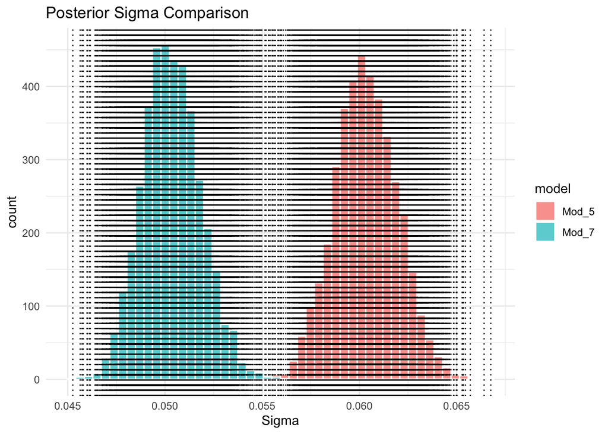

```r
# Assuming combined_posterior doesn't have a 'model' column
combined_posterior <- bind_rows(
  mutate(as.data.frame(Mod_7), model = "Mod_7"),
  mutate(as.data.frame(Mod_5), model = "Mod_5")
)

# Visualize posterior sigma with ggplot
combined_posterior %>%
  ggplot(aes(x = sigma, fill = model)) +
  geom_histogram(bins = 50, position = "identity", alpha = 0.7, color = "white") +
  geom_vline(aes(xintercept = sigma), linetype = "dotted", size = 0.5) +
  labs(title = "Posterior Sigma Comparison", x = "Sigma") +
  theme_minimal()
```

**Compute the numbers on the best model.**

```r
sprintf("Posterior mode σ: %.3f", sigma(Mod_7))
```

```
## [1] "Posterior mode σ: 0.050"
```

```r
sprintf("MLE estimated σ: %.3f", sigma(re_load_mod07))
```

```
## [1] "MLE estimated σ: 0.045"
```

- For the best model identified as `Model_7`:
  - The posterior mode of σ from the Bayesian model is around 0.050.
  - The corresponding MLE estimated of σ is 0.045.